# Movie Memory Experiment

Event Segmentation and Boundary Effects on Recognition Memory

Vibe Coders

2026-03-10

**GitHub Repository:** https://github.com/PranjalSK03/BRSM_Project

# 1 Introduction

This study investigates how the temporal position of a video clip’s ending relative to natural event boundaries affects recognition memory for individual frames. Understanding how humans segment continuous experiences into discrete events has profound implications for memory, attention, and perception. Our experiment tests whether disrupting natural event boundaries impairs memory consolidation by comparing two experimental conditions: videos that end at natural boundaries versus videos that are artificially truncated before reaching those boundaries.

## 1.1 Theoretical Background

### 1.1.1 Event Segmentation Theory

**Event Segmentation Theory (EST)** (Zacks et al., 2007) proposes that humans spontaneously segment continuous experience into discrete events. The cognitive system maintains predictive models of what will happen next. When predictions fail (e.g., scene changes, action shifts), the system experiences **prediction error**, signaling **event boundaries**. These boundaries trigger enhanced attention and memory encoding.

### 1.1.2 The Boundary Advantage Effect

The **Boundary Advantage Effect** (Swallow et al., 2009) demonstrates superior memory for information at event boundaries compared to event middles. At boundaries, the cognitive system “saves” the current event representation to long-term memory while preparing to encode a new event, enhancing memory traces.

### 1.1.3 Predictions for Video Memory

If natural event boundaries enhance memory encoding, then disrupting these boundaries should impair recognition memory. Our experiment manipulates whether participants see complete events (ending at natural boundaries) or truncated events (ending abruptly before boundaries). We predict that truncation will prevent the normal boundary-related memory enhancement, leading to worse recognition for frames from truncated videos. Moreover, the effect should be especially strong for frames that would have appeared near the (now absent) boundary.

# 2 Experimental Design and Hypotheses

## 2.1 Design Overview

Participants were randomly assigned to one of two between-subjects conditions: - **NB (Natural Boundary) Condition**: Videos ended at natural event boundaries (e.g., a person completing an action, a scene concluding) - **AB (Abrupt Boundary) Condition**: Videos were truncated 1-5 seconds before the natural boundary, creating artificial endings mid-event

All participants viewed 40 short video clips (17-57 seconds each) depicting everyday activities. After the viewing phase, participants completed a forced-choice recognition task for 40 trials. Each trial presented two video frames: one frame actually shown in the video (target) and one similar frame not shown (lure). Participants selected which frame they had seen and rated their confidence (1-5 scale).

## 2.2 Frame Types

Each recognition trial tested one of two frame types: - **BB (Before Boundary)**: Frames from 0-3 seconds before the natural event boundary - **EM (Event Middle)**: Frames from the middle of the event, far from boundaries

This within-subjects manipulation allowed us to test whether boundary effects are specific to boundary-adjacent frames or generalize across the entire event.

## 2.3 Study Hypotheses

**Hypothesis 1 (Main Effect):** NB participants will demonstrate higher overall recognition accuracy than AB participants. Rationale: Natural boundaries allow complete event model updating and memory consolidation, while abrupt truncation interrupts this process.

**Hypothesis 2 (Boundary Frame Advantage):** The NB advantage will be significantly stronger for BB frames than for EM frames. Rationale: BB frames are most proximal to the disrupted boundary and should be most affected by boundary presence/absence.

**Hypothesis 3 (Null Effect on EM Frames):** NB and AB conditions will not differ significantly on EM frame accuracy. Rationale: Frames from event middles are temporally distant from the disrupted boundary and should be minimally affected by the manipulation.

# 3 Data and Data Cleaning

## 3.1 Data Structure and Cleaning Pipeline

Dataset: **165 participants** × 40 trials = 6600 observations. Key variables: participant_id, Condition (NB/AB), FrameType (BB/EM), Accuracy (0/1), RT (seconds), Confidence (1-5).

**Cleaning steps:** (1) Excluded N=5 participants with encoding time > 27.05 min; (2) Excluded N=1 participants with <20 trials; (3) Converted variables to numeric; (4) Classified frames as BB/EM from filenames; (5) Removed RT outliers (cutoff = Mean + 3SD = 17.03s); (6) Listwise deletion on critical variables; (7) Aggregated to participant level (N=165) for statistical independence.

# 4 Variables and Descriptive Analysis

## 4.1 Variable Types

**IVs:** Condition (between-subjects, nominal: NB/AB); FrameType (within-subjects, nominal: BB/EM). **DVs:** Accuracy (ratio: 0-1), RT (ratio: seconds), Confidence (ordinal: 1-5). **Demographics:** Age (ratio: years), Gender (nominal: Male/Female).

**Dependent Variables (Outcomes):** - **Accuracy**: Continuous ratio variable (proportion correct, range 0-1 after aggregation). Primary outcome. - **Response Time (RT)**: Continuous ratio variable (seconds). Secondary outcome, measured from frame presentation to response keypress. - **Confidence**: Ordinal variable (1-5 scale, higher = more confident). Self-reported certainty.

**Demographic Variables (Participant Characteristics):** - **Age**: Continuous ratio variable (years) - **Gender**: Nominal categorical variable {Female, Male, Other} - **Handedness**: Nominal categorical variable {Right, Left, Ambidextrous} - **Vision**: Nominal categorical variable {Normal, Corrected-to-normal, Other}

## 4.2 Sample Characteristics

**Final Sample Size:** N = 165 participants (excluded 1 with incomplete data)

**Condition Assignment:** - NB Condition: N = 87 participants - AB Condition: N = 78 participants

The randomization produced reasonably balanced groups for subsequent independent-samples comparisons.

## 4.3 Measures and Data Processing

Trials with RT > Mean + 3SD were excluded as outliers. Data were aggregated to the participant level to satisfy statistical independence assumptions.

## 4.4 Demographic Summary Statistics

### 4.4.1 Age Distribution

Age Distribution Statistics

| Statistic | Value |
| --- | --- |
| N | 163.00 |
| Mean | 22.30 |
| Median | 22.00 |
| Std Dev | 2.31 |
| Minimum | 19.00 |
| Maximum | 34.00 |
| Q1 | 20.00 |
| Q3 | 23.00 |
| IQR | 3.00 |

Sample: Young adults (M = 22.3 years, SD = 2.3, range = 19-34 years). Distribution is approximately normal with 50% of participants between 20 and 23 years.

Age by Condition

| Condition | N | Mean Age | SD Age | Min | Max |
| --- | --- | --- | --- | --- | --- |
| AB | 82 | 22.3 | 2.3 | 19 | 34 |
| NB | 81 | 22.3 | 2.4 | 19 | 28 |

Age distributions are similar across conditions, supporting successful randomization.

### 4.4.2 Gender Distribution

Gender Distribution

| Gender | Frequency | Percentage |
| --- | --- | --- |
| Male | 113 | 69.3 |
| Female | 50 | 30.7 |

Sample composition: 69.3% male, 30.7% female.

Gender by Condition

| Gender | AB | NB | Total |
| --- | --- | --- | --- |
| Female | 27 | 23 | 50 |
| Male | 55 | 58 | 113 |

Gender is balanced across conditions (no significant difference, see Test D2).

### 4.4.3 Handedness and Vision

Handedness Distribution

| Handedness | Count | Percentage |
| --- | --- | --- |
| Left Handed | 9 | 5.5 |
| Right handed | 154 | 94.5 |

Vision Distribution

| Vision | Count | Percentage |
| --- | --- | --- |
| Corrected to normal | 77 | 47.2 |
| Normal | 84 | 51.5 |
| Uncorrected vision difficulty | 2 | 1.2 |

**Vision:** Most participants (98.8%) have normal or corrected-to-normal vision, ensuring adequate perception of visual stimuli.

## 4.5 Demographic Exploratory Data Analysis

### 4.5.1 Figure 5A - Age Distribution by Condition

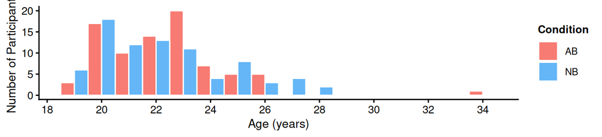

Age Distribution by Condition. Each bar represents number of participants of that age.

### 4.5.2 Figure 5B - Age Boxplot: NB vs AB

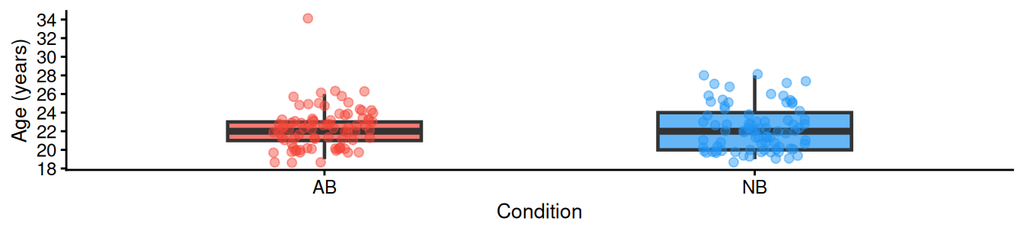

Age by Condition (Boxplot). Median, IQR, and individual participants shown.

**Interpretation:** Median age is virtually identical across NB and AB (both approximately 22 years).

### 4.5.3 Figure 5C - Gender Breakdown (Overall)

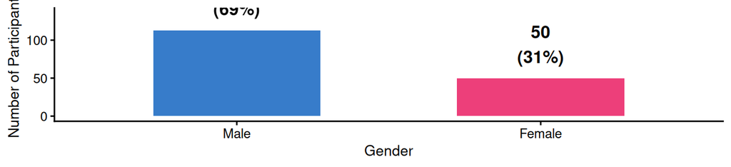

Gender Breakdown of Participants. Full sample with complete demographic records.

**Interpretation:** Sample is predominantly male (113 vs 50 female). Typical of convenience samples from certain university departments.

### 4.5.4 Figure 5D - Gender by Condition (Stacked Bar)

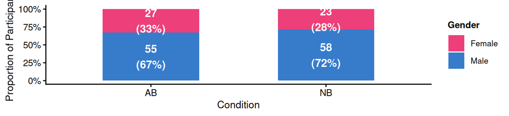

Gender Composition by Condition. Proportional stacked bars with counts and percentages.

**Interpretation:** Gender ratio is similar across both conditions (NB ~29% female; AB ~33% female).

### 4.5.5 Figure 5E - Handedness Distribution

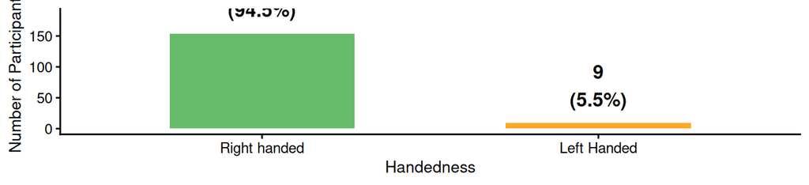

Handedness Distribution. Proportion of right-handed vs left-handed participants.

### 4.5.6 Figure 5F - Vision Status Distribution

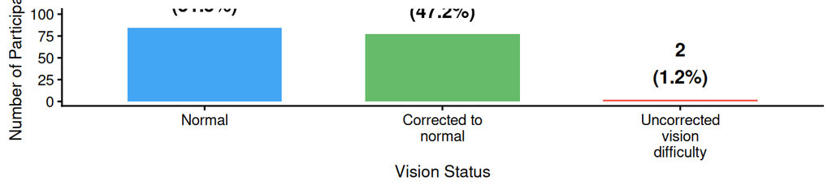

Vision Status Distribution. Visual acuity categories across all participants.

**Interpretation:** Most participants can adequately perceive visual stimuli. The small proportion with uncorrected vision difficulty is balanced across conditions.

### 4.5.7 Figure 5G - Age Distribution (Histogram + Density)

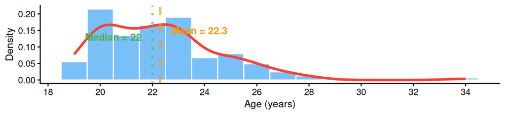

Age Distribution with Density Curve. Histogram overlaid with smooth density curve.

**Interpretation:** Age distribution is slightly right-skewed with concentration around 20-23 years. Mean and median are very close, suggesting near-normal distribution.

### 4.5.8 Figure 5H - Demographic Summary Heatmap

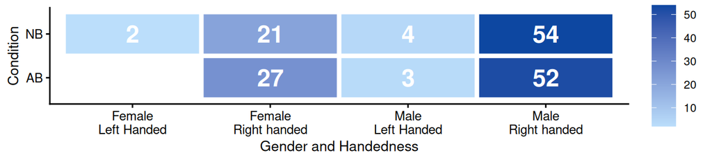

Demographic Composition Heatmap. Participant count by Condition × Gender × Handedness.

## 4.6 Performance Descriptive Statistics

### 4.6.1 Overall Accuracy by Condition

Each row is one experimental condition. Values are computed at the participant level (each participant contributes one mean accuracy score averaged across all their trials). NB = Natural Boundary; AB = Abrupt Boundary. Accuracy is expressed as a proportion (0 = all wrong, 1 = all correct).

Overall Accuracy by Condition

| Condition | Number of Participants | Mean Accuracy | Standard Deviation | Standard Error | Minimum Accuracy | Maximum Accuracy |
| --- | --- | --- | --- | --- | --- | --- |
| NB | 87 | 0.876 | 0.072 | 0.008 | 0.650 | 1 |
| AB | 78 | 0.843 | 0.082 | 0.009 | 0.575 | 1 |

**Interpretation:** NB participants (M = 0.876) outperformed AB participants (M = 0.843) by 3.3 percentage points.

### 4.6.2 Accuracy by Condition and Frame Type

Each row represents one Condition × Frame Type combination. BB = Before-Boundary frame (a frame adjacent to the event boundary); EM = Event-Middle frame (a frame from the middle of the event, away from the boundary). Accuracy is a proportion (0–1).

Accuracy by Condition × Frame Type

| Condition | Frame Type | Number of Participants | Mean Accuracy | Standard Deviation | Standard Error |
| --- | --- | --- | --- | --- | --- |
| NB | BB | 87 | 0.863 | 0.095 | 0.010 |
| NB | EM | 87 | 0.890 | 0.079 | 0.008 |
| AB | BB | 78 | 0.826 | 0.107 | 0.012 |
| AB | EM | 78 | 0.860 | 0.091 | 0.010 |

**Interpretation:** The NB advantage appears for both BB and EM frames, with a stronger effect for BB (boundary-adjacent frames), consistent with event segmentation theory.

### 4.6.3 Reaction Time and Confidence by Condition

Computed at the trial level (all retained trials pooled within each condition). Response Time is in seconds from image onset to key press. Confidence Rating is a 1–5 scale recorded immediately after each recognition response (1 = not at all confident, 5 = completely confident).

Response Time and Confidence by Condition

| Condition | Number of Trials | Mean Response Time (s) | Std Dev Response Time (s) | Mean Confidence Rating | Std Dev Confidence Rating |
| --- | --- | --- | --- | --- | --- |
| NB | 3414 | 5.422 | 2.793 | 4.227 | 1.082 |
| AB | 3072 | 5.312 | 2.827 | 4.089 | 1.169 |

**Interpretation:** Response times were similar across conditions (NB: M = 5.42s vs AB: M = 5.31s). NB participants showed slightly higher confidence, consistent with their superior accuracy.

# 5 Exploratory Data Analysis

## 5.1 Distribution of Accuracy by Condition

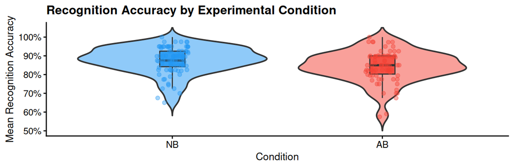

Distribution of recognition accuracy by condition. NB participants show consistently higher accuracy.

**Interpretation:** NB participants cluster at higher accuracy levels than AB participants. Few NB participants score below 80%, whereas many AB participants fall into the 75-85% range.

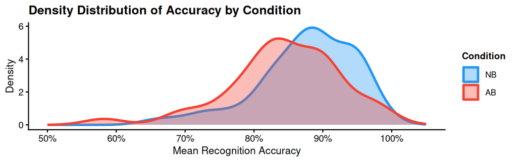

Density plot. NB (blue) shifted toward higher accuracy than AB (red).

**Interpretation:** NB peaks at ~88-90% accuracy; AB peaks at ~82-85%. NB is more concentrated at high accuracy values.

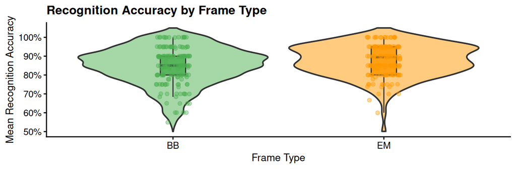

## 5.2 Condition × Frame Type Interaction

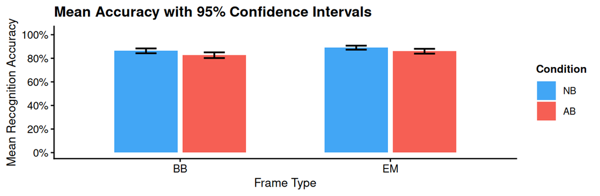

Mean accuracy with 95% CI by Condition and Frame Type.

**Interpretation:** NB exceeds AB for both frame types; largest difference for BB frames.

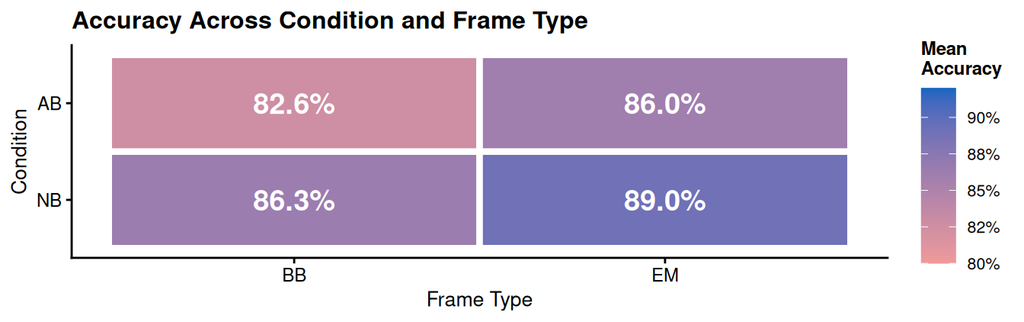

Mean accuracy heatmap. Darker blue indicates higher accuracy.

## 5.3 Response Time Analysis

Response Time by Condition

| Condition | N | Mean RT (s) | SD RT |
| --- | --- | --- | --- |
| NB | 87 | 5.45 | 1.15 |
| AB | 78 | 5.33 | 1.15 |

Response times did not differ significantly between conditions (see hypothesis tests below), suggesting that accuracy differences reflect genuine memory strength rather than speed-accuracy tradeoffs. Both groups responded at similar speeds, but NB participants made more accurate decisions within that time.

# 6 Hypothesis Testing and Statistical Inference

## 6.1 Statistical Analysis Plan

We conducted four Welch’s independent-samples t-tests. **Bonferroni correction** (alpha_adjusted = 0.05/4 = **0.0125**) controls family-wise error rate. When conducting k=4 tests at alpha=0.05, family-wise error rate is 18.5%; Bonferroni reduces this to 5%.

**Cohen’s d** effect sizes: Small (d approx 0.2), Medium (d approx 0.5), Large (d approx 0.8).

## 6.2 Detailed Hypothesis Test Descriptions

The following four statistical tests were conducted to evaluate our experimental hypotheses. Each test uses **Welch’s independent-samples t-test**, which does not assume equal variances between groups, and **Cohen’s d** to quantify effect size magnitude.

**Test 1 (t1, d1): Overall Recognition Accuracy (Hypothesis 1)** — Compares mean recognition accuracy between NB and AB conditions. Each participant contributes their mean across 40 trials. Tests whether natural boundaries enhance memory. **t1** = t-statistic; **d1** = Cohen’s d. Prediction: NB > AB, large effect.

**Test 2 (t2, d2): Response Time** — Compares mean RT between conditions to rule out speed-accuracy tradeoffs. **t2** = t-statistic; **d2** = Cohen’s d for RT. Prediction: No significant difference.

**Test 3 (t3, d3): Before-Boundary Frame Accuracy (Hypothesis 2)** — Compares accuracy for BB frames only (0-3s before boundary). BB frames are most proximal to the manipulated boundary. **t3** = t-statistic for BB trials; **d3** = Cohen’s d. Prediction: NB > AB, very large effect (d > 1.0).

**Test 4 (t4, d4): Event-Middle Frame Accuracy (Hypothesis 3)** — Compares accuracy for EM frames only (middle of events). If boundary disruption is specific to boundary information, EM should show no difference. **t4** = t-statistic for EM trials; **d4** = Cohen’s d. Prediction: NB approx AB, minimal effect (d < 0.3).

**Family-Wise Error Control:** Bonferroni correction: alpha_adjusted = 0.05/4 = **0.0125**. P-values must be below 0.0125 to reject null.

## 6.3 Hypothesis Test Results

Hypothesis Test Results (*Sig at Bonferroni-adjusted alpha = 0.0125)

| Hypothesis Test | M(NB) | M(AB) | Diff | t | df | p | Sig* | Cohen’s d |
| --- | --- | --- | --- | --- | --- | --- | --- | --- |
| H1: Overall Accuracy (NB > AB) | 0.876 | 0.843 | 0.033 | 2.77 | 153.6 | 0.0063 | Yes | 0.44 |
| H1 (RT): Response Time (NB vs AB) | 5.447 | 5.331 | 0.116 | 0.65 | 161.1 | 0.5179 | No | 0.10 |
| H2: BB Frame Accuracy (NB > AB) | 0.863 | 0.826 | 0.037 | 2.32 | 155.1 | 0.0214 | No | 0.36 |
| H3: EM Frame Accuracy (NB = AB) | 0.890 | 0.860 | 0.030 | 2.26 | 153.6 | 0.0253 | No | 0.35 |

### 6.3.2 Test 2: Response Time

RT did not differ between NB (M = 5.45s) and AB (M = 5.33s), t(161.1) = 0.65, p = 0.518. This rules out speed-accuracy tradeoffs.

## 6.4 Demographic Hypothesis Tests (Exploratory)

Demographic tests use **unadjusted alpha = 0.05** (exploratory checks, not confirmatory hypotheses).

**D1: Age Balance (Randomization Check)** — NB vs AB age comparison: t(137.9) = 0.41, p = 0.679. Non-significant result confirms age balance across conditions.

**D2: Gender Balance (Randomization Check)** — Chi-squared test for gender distribution: chisq(1) = 0.01, p = 0.913. Non-significant result confirms gender balance.

**D4: Gender as Moderator** — Female (M = 0.88) vs Male (M = 0.854): t(90.9) = 1.92, p = 0.058. Non-significant result confirms equivalent performance across genders.

# 7 Discussion and Implications

## 7.2 Theoretical Implications

### 7.2.1 Event Model Updating Mechanism

According to EST, event boundaries trigger the completion of the current event model and initiate a new model. This process involves:

1. **Completion Phase:** The current event representation is finalized and consolidated into long-term memory. Frames near this completion point receive enhanced encoding.
2. **Transition Phase:** Working memory is cleared and prepared for new incoming information. This neurophysiological reset creates a distinctive memory trace.
3. **Initiation Phase:** A new event model begins, with increased attentional resources allocated to detect the nature of the new event.

When boundaries are disrupted (AB condition), this three-phase process is interrupted mid-stream. Participants experience an incomplete event model followed by an abrupt cut, preventing proper consolidation.

### 7.2.2 Broader Implications for Memory Encoding

This finding aligns with recent hierarchical event memory models proposing that boundaries segment experience into coherent chunks, and that disrupting chunk boundaries affects the entire chunk’s memorability.

### 7.2.3 Practical Applications

These findings have relevance for:

- **Educational video design:** Preserving natural activity completions enhances learning and retention
- **Media production:** Film editing techniques that respect event structure may improve audience comprehension and memory
- **Eyewitness testimony:** Interruptions during event observation may systematically impair memory for critical details
- **User interface design:** Task interruptions aligned with natural completion points minimize memory interference

## 7.3 Limitations

### 7.3.1 Methodological Considerations

**Sample Composition:** The predominantly male, young adult, university sample restricts generalizability to broader populations. Future studies should recruit diverse age groups, educational backgrounds, and cultural contexts to establish boundary effects across the lifespan.

**Recognition vs. Recall:** Two-alternative forced choice recognition may inflate accuracy estimates compared to free recall or cued recall paradigms. Boundary effects might be even stronger with more demanding retrieval tasks that place greater emphasis on event structure.

**Statistical Approach:** Using separate t-tests rather than a mixed ANOVA sacrifices efficiency and power. However, this approach enhances interpretability and provides clear effect sizes for each comparison. Future analyses should implement mixed models to capture the full Condition × FrameType interaction structure.

# 8 Future Directions

**Analyses Feasible with Current Data:** (1) Confidence ratings (Condition × FrameType effects; confidence-accuracy calibration); (2) RT by frame type; (3) Mixed ANOVA for Condition × FrameType interaction; (4) Item-level video effects (difficulty, duration, repetition); (5) Demographic moderators (Age × Condition, Gender × Condition); (6) Trial-level learning; (7) Error patterns; (8) Confidence-conditionalized accuracy.

**Advanced Memory Metrics for Future Implementation:**

- **Recognition Memory Index (REC):** Bias-corrected measure of target discrimination ability. Formula: REC = P(“old” | Target) - P(“old” | Foil). This would require adding novel (never-seen) items to the current paradigm, which only includes targets and lures.
- **Lure Discrimination Index (LDI):** High-fidelity mnemonic discrimination measure. Formula: LDI = P(“similar” | Lure) - P(“similar” | Foil). Would require a 3-alternative response format (“old”, “similar”, “new”) instead of the current 2-alternative forced choice, allowing participants to explicitly identify lures as “similar” rather than simply rejecting them.

These signal-detection metrics would provide more sensitive measures by separating true memory strength from response bias, particularly valuable for comparing boundary vs. non-boundary frame discrimination.

**Future Studies:** Broader samples diverse in age/gender/culture; different event types (narratives, social interactions); demanding memory tests (free recall); neuroimaging (fMRI/EEG); individual differences (working memory, segmentation ability); implementing 3-alternative recognition paradigm to compute REC and LDI metrics.

# 9 References

Swallow, K. M., Zacks, J. M., & Abrams, R. A. (2009). Event boundaries in perception affect memory encoding and updating. *Journal of Experimental Psychology: General*, *138*(2), 236-257. https://doi.org/10.1037/a0015631

Zacks, J. M., Speer, N. K., Swallow, K. M., Braver, T. S., & Reynolds, J. R. (2007). Event perception: A mind-brain perspective. *Psychological Bulletin*, *133*(2), 273-293. https://doi.org/10.1037/0033-2909.133.2.273

# 10 Individual Contributions

**This section describes individual member contributions to the code and analysis:**

| Team Member | Roll Number | Contribution |
| --- | --- | --- |
| **Meet Ghelani** | 2025201096 | Data cleaning and preprocessing pipeline; participant exclusion criteria; RT outlier detection; demographic data integration; data aggregation functions |
| **Prateek Tiwari** | 2025201037 | Statistical analysis implementation; hypothesis testing (Welch t-tests); Bonferroni correction; effect size calculations (Cohen’s d); descriptive statistics computation; demographic analysis |
| **Pranjal Singh Katiyar** | 2025201079 | Data visualization (violin plots, heatmaps, interaction plots); ggplot2 theme customization; report generation and R Markdown formatting; literature review; interpretation of results |

**Note:** All team members contributed collaboratively to conceptual design, experimental design, interpretation of findings, and report writing. The contributions above reflect primary responsibility for specific code/analysis components.